# Simulating a 16-way MAGIC population with magicsim

Sarah Odell

2/27/2019

## Simulating a 16-way MAGIC population with magic sim

The following uses magicsim to simulate 400 double haploid maize lines that were derived from a 16-way Multi-parent Advanced Generation InterCross (MAGIC) funnel crossing scheme.

A x B | C x D | E x F | G x H | I x J | K x L | M x N | O x P |

| AB x CD | EF x GH | IJ x KL | MN x OP | | |

| | ABCD x EFGH | IJKL x MNOP | | | | |

| | ABCDEFGH x IJKLMNOP | | | | | |

### Initializing Founder lines

magicsim simulates recombination evens using a genetic map of the organism. In this case, we are using a genetic map of maize generated by Ogut et al. (2015).

We will do this for maize chromosome 1 only, although this can be done for any number of chromosomes.

```r
gmap=fread('ogutmap_v4_ordered.csv',data.table=F)

# The 16 founder maize inbred lines. This could be anything
founders=c("A632","B73","CO255_inra","FV252",
           "OH43","A654","FV2","C103",
           "EP1","D105","W117","B96","DK63",
           "F492","ND245","VA85")

cross_order=c(2,4,14,15,3,8,10,16,1,9,5,6,12,7,11,13)
cross_info=founders[cross_order]


### Simulate chromosome 1
c=1
### Initialize the 16 founders
founderpop=pop_init(n=16,chroms=c,donors=cross_info,g_map=gmap,poptype="magic")
```

### Create the first round of F1s

Using the crossing order above and the simulated founder chromosomes, we can create F1s from the first round of crossing of the MAGIC crossing scheme.

```r
### Create F1s from the first round of crossing
#Create an empty Pop object
f1s=new("Pop",nIndv=8,indvlist=vector("list",length=8))

#Make F1s for each of the first crosses and add to the Pop object
count=1
for(i in seq(1,16,2)){
  f1s@indvlist[[count]]=make_f1(founderpop[i],founderpop[i+1],gmap,chroms=c)
  count=count+1
}
```

### Building a MAGIC Population.

Create synthetic population of 1000 lines from MAGIC founder funnel

Look at number of recombinations in magic f4 lines

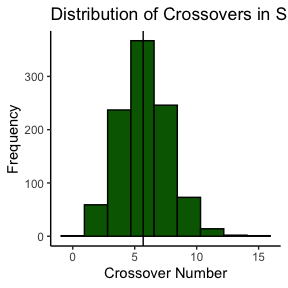

```r
#what is the distribution of xo_no in the population?
total_xo=c()
for(i in seq(1,1000)){total_xo=c(total_xo,magic_pop[i][1]@h1@xo_no)}

crossovers=data.frame(ind=seq(1,1000),xo_no=total_xo)
ggplot(crossovers,aes(x=xo_no)) + geom_histogram(bins=9,fill="darkgreen",color="black") + theme_classic() +
  ggtitle("Distribution of Crossovers in Simulation MAGIC Population") + xlab("Crossover Number") +
  ylab("Frequency") + geom_vline(xintercept=mean(crossovers$xo_no))
```

What do they look like? Convert the Pop object to a breaktable to visualize crossovers. Here is one for just 10 of the lines. Can specify heterozygous or homozygous

```r
breaktable=make_pop_breaktable(magic_pop,n=10,c=1,het=T)
head(breaktable)
```

```
##   sample chr hom     start       end      donor
## 1   Sim1   1  H1         0  16507699       F492
## 2   Sim1   1  H1  16507700  61428210        B73
## 3   Sim1   1  H1  61428211 189043900       C103
## 4   Sim1   1  H1 189043901 212963524 CO255_inra
## 5   Sim1   1  H1 212963525 237890896       VA85
## 6   Sim1   1  H1 237890897 306879533 CO255_inra
```

### Visualization

Plotting some of the lines can be useful in seeing how representative the simulated lines are.

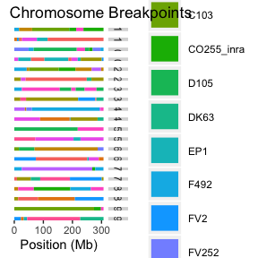

```r
plot_Pop(breaktable,n=10,c=1,het=T)
```

```r
# Plotting can be done as heterozygous or homozygous
```

### Simulate Outcrossing

Random outcrossing within the synthetic population of 1000 individuals for 3 generations

Look at number of recombinations in synthetic 3 lines

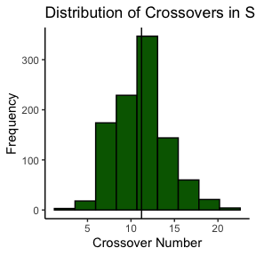

```r
#what is the distribution of xo_no in the population?
total_xo=c()
for(i in seq(1,1000)){total_xo=c(total_xo,synth_pop[i][1]@h1@xo_no)}

crossovers=data.frame(ind=seq(1,1000),xo_no=total_xo)
ggplot(crossovers,aes(x=xo_no)) + geom_histogram(bins=9,fill="darkgreen",color="black") + theme_classic() +
  ggtitle("Distribution of Crossovers in Simulation Synth3 Population") + xlab("Crossover Number") +
  ylab("Frequency") + geom_vline(xintercept=mean(crossovers$xo_no))
```

### Get Doubled Haploids

Randomly select 400 lines from the synthetic population and then choose one of the chromosomes at random to duplicate

```r
#randomly choose 400 out of the 1000
dh_pop=make_dh_pop(synth_pop,n=400,c=1,gmap)
```

### Assessing the simulated lines

Looking at number of crossovers

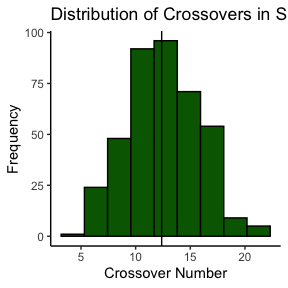

```r
no=sapply(seq(1,400),function(x) length(dh_pop[x][1]@h1@donors))
#what is the distribution of xo_no in the population?
total_xo=c()
for(i in seq(1,400)){total_xo=c(total_xo,dh_pop[i][1]@h1@xo_no)}

crossovers=data.frame(ind=seq(1,400),xo_no=total_xo)
ggplot(crossovers,aes(x=xo_no)) + geom_histogram(bins=9,fill="darkgreen",color="black") + theme_classic() +
  ggtitle("Distribution of Crossovers in Simulation DH Population") + xlab("Crossover Number") +
  ylab("Frequency") + geom_vline(xintercept=mean(crossovers$xo_no))
```

Convert the dh_pop object into breakpoints dataframe

```r
#This should be its own function
breaktable=make_pop_breaktable(dh_pop,n=10,c=1,het=F)
head(breaktable)
```

```
##   sample chr hom     start       end donor
## 1   Sim1   1  H1         0   6636668  D105
## 2   Sim1   1  H1   6636669  45522418  VA85
## 3   Sim1   1  H1  45522419 244545894  C103
## 4   Sim1   1  H1 244545895 269147623   FV2
## 5   Sim1   1  H1 269147624 292621402 FV252
## 6   Sim1   1  H1 292621403 297153943   FV2
```

### Visualization

Plotting some of the lines can be useful in seeing how representative the simulated lines are.

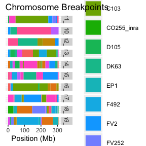

```r
plot_Pop(breaktable = breaktable,n=10,c=1,het=F)
```